# DS 2006 Midterm 1 Test Questions

**NOTE:** The `.rmd` version of the file is available here: [(link)](https://tgstewart.cloud/midterm1.rmd)

## Instructions

Please prepare reponses/solutions for the following questions. On the day of the exam, you will be given a new set of questions. You will use the solutions you’ve prepared for this exam during the exam.

During the exam, you will also be permitted to access the internet for publicly available content. You will not be allowed to communicate with anyone via the internet or any other means during the exam. This includes, but is not limited to:

- No messaging, emailing, or using social media to contact others.
- No posting questions or seeking answers on forums, chat rooms, chat bots (including large language models like ChatGPT), or any collaborative platforms.
- No sharing or discussing exam content with peers through any online or electronic medium.

You may **NOT** discuss any aspect of the exam or prep questions without other than the instructor or TA. You may **NOT** share code or documents.

## Submission instructions

1. Within your course repo, create a folder called `Midterm1`
2. Within the folder, create the script file `exam.rmd` with your solutions. Create a rendered report in `.md` or `.html` output.
3. Add, commit, and push to your repo on github.com.

## Questions

Exam questions are organized into sections cooresponding to the learning outcomes of the course.

### Section 1. Tools of the data scientists

> Learning objective: Use the tools of data scientists, including
> - R
> - IDE (Rstudio or VScode)
> - Git
> - Github
> - Markdown
> - Rmarkdown
> - Rivanna

> Learning objective: Implement best practices, including
> - Reproducible reports
> - Working directory
> - Relative file paths

1.1 [4 pts] The following is an `.rmd` script which performs a simulation study and summarizes the results. Please modify the script so that the output format of the report is an `.md` file.

````markdown
---
title: "Probability of shared birthday"
output: md_document
---

```{r birthday-probs}
first_duplicate <- function(){
    sample(1:365, 366, replace=TRUE) |>
    duplicated() |>
    which() |>
    min()
}

R <- 10000
fd1 <- replicate(R, first_duplicate())
plot(ecdf(fd1), main = "Probability of shared birthday", xlab = "Class size")
```
````

1.2 [4 pts] The following is the file structure which resulted after rendering `script.rmd`. Notice that the output files were not saved in the project folder. What mistake was made and how could it be fixed?

```
home
│
├── desktop
│   ├─── script.md
│   │
│   └─── script_files
│        │
│        └─── figure-markdown_strict
│             │
│             └─── birthday-probs-1.png
|
└── project
    │
    ├─── code
    │    └─── script.rmd
    │
    ├─── data
    │    └─── survey-responses.csv
    │
    └─── docs
```

This could be fixed by setting your working directory as the project folder. You can you this with the code `setwd()` or by clicking “session” > “set working directory” > “To source file location”. You can then check that your working directory is correct by using the code `getwd()`. for example, when I check this document I get back “/Users/oliviapark/Documents/GitHub/ds2006-park-olivia/Midterm 1”.

1.3 [4 pts] The contents of `script.md` are below. What does the final line of the file do?

```
    first_duplicate <- function(){
        sample(1:365, 366, replace=TRUE) |>
        duplicated() |>
        which() |>
        min()
    }

    R <- 10000
    fd1 <- replicate(R, first_duplicate())
    plot(ecdf(fd1), main = "Probability of shared birthday", xlab = "Class size")

![](test_files/figure-markdown_strict/birthday-probs-1.png)
```

The final line of code would save the figure created by the previous code as a .png.

1.4 [4 pts] The report `script.md` is a text file, and consequently does not show images when viewed in a text editor. How does one view the report so that is shows the figures?

You should render it as an .html document in order to be able to see figures and pictures.

1.5 [4 pts] The following error was generated in R. How might the error be resolved?

```
Error in loadNamespace(x) : there is no package called ‘data.table’
```

to resolve this error, we must first install the package: `install.packages("data.table")` then we can open the library: `library(data.table)` before rendering the document, we should be sure to # out the `install.packages’

### Section 2. Probability

> Learning objective: Compare and contrast different definitions of probability, illustrating differences with simple examples

> Learning objective: Express the rules of probability verbally, mathematically, and computationally
> - AND, OR, complement, total probability
> - simulation error (relative and absolute)

2.1 [4 pts] What is probability? Please illustrate with examples of different types of probability.

Probability is the measure of the likely hood that an event will occur. There are three main types of probability. The first type is a frequency probability, which measures the long-run average of an events occurrence. an example would be if I flip a coin some number of times, the proportion of times is lands on tails is the probability of landing on tails. The second type is an expression of belief, which communicates the degree of certainty about something. An example is a jury saying that there is a 90% chance that the defendant is guilty. The final type of probability is a data informed belief, which starts with a belief and uses data to update and validate that belief. This lies between the two previous categories, and an example is scientist’s claiming that a medicine has an 75% chance of curing an illness.

2.2 [20 pts] Machines A, B, and C generate widgets with a defect rate of 0.1, 0.01, and 0.001, respectively. Machine A generates twice as many widgets as B, and machine B generates twice as many widgets as machine C.

Please complete the cross table below based on the information above.

Hints:

- P(A) = 2*P(B) = 4*P(B), which means P(A) = 4/7, P(B) = 2/7 and P(C) = 1/7.
- What type of probability is the defect rate? Where does this probability appear in the table?

[output not shown]

2.3 [8 pts] If you did not know if a widget was functional or defective, what would be the probability that the widget is from machine A? Write the solution using mathematical notation, as in P(???) = ???.

P(WidgetA) = 4/7 = .5714

2.4 [8 pts] How would you update the probability from 2.3 if you knew the widget was defective? Write the solution using mathematical notation, as in P(???) = ???.

### Section 3. Simulation

> Learning objective: Use probability models to build simulations of complex real world processes to answer research questions

3.1 [12 pts] The following function simulates the widget problem from 2.2. Create the cross table from 2.2 empirically, using the function to mimic the manufacture of many widgets and generating the resulting cross table.

```r
widgets <- function(R){
    machine <- sample(c("A","B","C"), R, replace=TRUE,prob=c(4,2,1)/7)
    defect <- rbinom(R,1,0.1*(machine=="A")+0.01*(machine=="B")+0.001*(machine=="C"))
    data.frame(machine=machine, defect=defect)
}

# in theory would use code from homework eight and use this fucntion to complete - I tired using the pander package and plugging in this fucntion to the CrossTable but I could not leave in the code when I uploaded so I took it out
```

[output not shown]

3.2 [8 pts] What is simulation error for P(machine A & defective)? (Hint: take the difference.)

The simulation error would be the error between our assumed number of errors from machine a and the actual number of error

3.3 [12 pts] In class and homework, you solved the birthday problem. The script we developed in class to solve the problem is below. Please change the code to answer a slightly different version of the birthday problem:

**In a class of size 55, what is the probability that at least 4 individuals will share a birthday?**

```r
generate_class <- function(class_size){
  sample(1:365, class_size, replace=TRUE)
}

generate_class(55) |>
  table()
```

```
##
##   2  14  15  25  27  30  67  69  72  74  84  91  92 101 104 109 113 157 161 165
##   2   1   1   1   1   2   1   1   1   1   1   1   1   1   1   1   1   1   1   1
## 169 179 188 198 207 209 211 212 214 223 225 234 235 236 239 241 243 255 257 262
##   1   1   1   1   1   1   1   1   1   1   1   1   1   1   1   1   1   1   1   1
## 267 269 277 281 283 293 303 305 310 314 341 351 365
##   1   1   1   1   1   1   1   1   1   1   1   1   1
```

```r
# use the table() function to sort the number of birthdays per day, then use the max() function to choose the number to times there are four or more birthdays on a single day

check_birthday <- function(class){
  class |>
  table() |>
  max() >= 4

}

set.seed(230583)
R <- 10000
replicates <- replicate(R, generate_class(55) |> check_birthday())
mean(replicates)
```

```
## [1] 0.0057
```

3.4 [8 pts] Generate a figure with class size on the x-axis, and the probability of a quadruply-shared birthday on the y-axis.

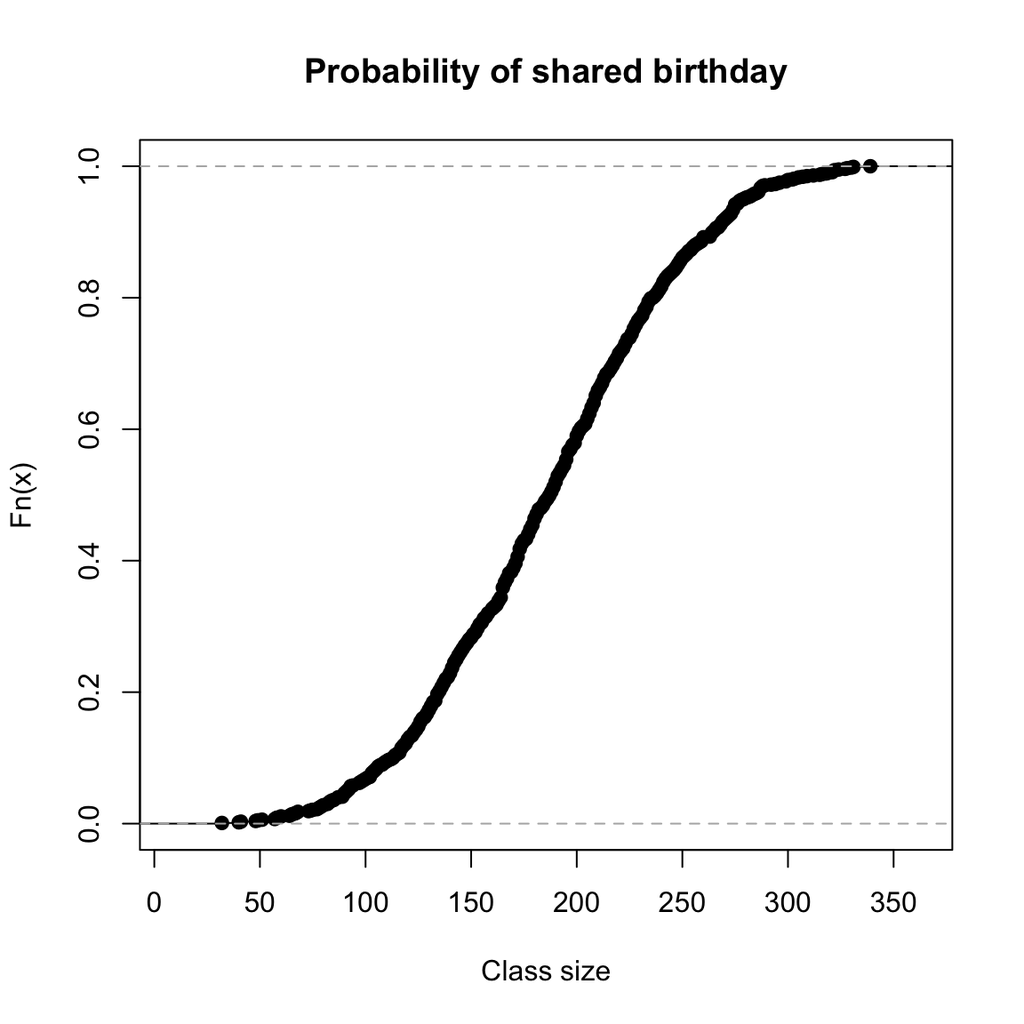

```r
first_duplicate <- function(k) {
  cr1 <- sample(1:365, 366*(k-1), replace=TRUE)
  for(i in 1:length(cr1)) {
    if(any(table(cr1[1:i]) >= k)) return(i)
  }
}

R <- 1000
fd1 <- replicate(R, first_duplicate(4))
plot(ecdf(fd1), main = "Probability of shared birthday", xlab = "Class size")
```

### Extra Credit

For one point extra credit, who is the greatest football prognosticator? (Hint: Olivia Park)

Olivia PArk (me) is the greatest football porgnostcator